# Data Wells: Race and State Violence in the United States from 1892

## A focus on “Data Wells”: *Data* + Ida B. *Wells*-Barnett

- We use the term “ Data Wells” to describe how we practice the identification, input, and storage of what can be termed as critical insights data, or CIDs.
- We use information in databases in four ways:
  1. studying problems in the quantification of historical information across various axes: time, social constructs, and/or systemic issues,
  2. data identification and wrangling,
  3. data analysis and communication, and
  4. modeling abstract inquiries.
- We begin our analysis with Ida B. Wells-Barnett’s organization and analysis of lynching.
- We describe “Data Wells” of U.S. state violence using quantitative history as a frame.

## On the Principles of Reconstruction

- Du Bois’ (1935) [Black Reconstruction: An Essay Toward a History of the Part which Black Folk Played in the Attempt to Reconstruct Democracy in America, 1860-1880](https://www.loa.org/books/698-black-reconstruction/) offers an alternative assessment of the post-Civil War period in the United States.
- Democracy provided a new narrative at the time to examine African American progress post enslavement, and it continued to challenge long-standing narratives about racial hierarchy.
- Recently, notable scholars, such as Gloria Ladson-Billings, return to the importance of narratives of *democracy* in relation to the promise and perils of education and society broadly, while also highlighting the limits of liberalism.

## Quantitative Histories Workshop

`Curriculum & software development collective`

and

research lab

[output not shown]

[output not shown]

[output not shown]

[output not shown]

[output not shown]

[output not shown]

## Racialization and U.S. State Violence

Today, we will discuss race and racialization in *data wells* of state sponsored violence:

. . .

- Lynching. Framing historical incidents and conceptualizing the contemporary formations of lynching.

. . .

- Policing. Understanding the role of policing in relation to both lynching and prisons.

. . .

- Prisons. Identifying narratives around prison populations and racialization.

## Lynching

Caitlin Pollock developed [maps](https://redrecord.cmjpollock.com/) using data extracted from Wells-Barnett’s work. Although the data provides for quick loading and analysis, it does require some data wrangling and other questions remain. We build on this data to examine the social implications of cartography and map making.

### 1893

Content for 1893

```
##                                                                             Names
## 1                               Paul Hill, Paul Archer, William Archer, Emma Fair
## 2                                                                   unknown negro
## 3                                                                   Calvin Thomas
## 4                                                                   Tillman Green
## 5                                                                   Patrick Wells
## 6                                                   Frank Harrell, William Filder
## 7                                                                    Richard Mays
## 8                                                                    Dug Hazleton
## 9                                                                    Judge McNeil
## 10                                                                    Frank Smith
## 11                                                                William Jackson
## 12                                                                   Riley Gulley
## 13                                                                     John Davis
## 14                                                                 Robert Kennedy
```

[output cut: 366 more lines]

### 1894

Content for 1894

```
##                                                                                                        Names
## 1                                                                                               Samuel Smith
## 2                                                                                            Sherman Wagoner
## 3                                                                                              Roscoe Parker
## 4                                                                                                Henry Bruce
## 5                                                                                           Sylvester Rhodes
## 6                                                                                             Richard Puryea
## 7                                                                                             Oliver Jackson
## 8                                                                                                   Saybrick
## 9                                                                                              William Lewis
## 10                                                                                          Jefferson Luggle
## 11                                                          Samuel Slaugate, Thomas Claxton, David Hawkins,
## 12                                                      Thel Claxton, Comp Claxton, Scot Harvey, Jerry McCly
## 13                                                                                               Henry Scott
## 14                                                                                             Coat Williams
```

[output cut: 306 more lines]

### 1895

Content for 1895

Sandra Bland, killed by police in 2015, Texas

Breonna Taylor, killed by police in 2020, Louisville

Rayshard Brooks, killed by police in 2020, Atlanta

George Floyd, killed by police in 2020, Minneapolis

## Fatal police interactions

[Alicia Chugtai (2020)](https://interactive.aljazeera.com/aje/2020/know-their-names/index.html) developed an interactive site, **Know their names**, that chronicles Black people killed by police in the United States.

[interactive chart not shown]

## Histories of police violence

- Ku Klux Klan origin and membership
- *American Policing: Protect Private Property, Not People*, by David Todd
- *The History of Police in America and the First Force*, by Olivia Waxman
- Cop Cities (see, Atlanta) and the militarization of local police

## Media Framing

In *Race and Police Brutality: The Importance of Media Framing* (Fridkin, 2017) the authors discuss how media framing can affect the audience’s perception of situations. Here, we disucss racialization.

- Emphasis frames
  - Black Americans make up 40 percent of the prison population.
  - History: “War on Crime,” “War on Drugs,” Jim Crow
- Equivalency frames
  - Black Americans make up a lower percdentage of police fatalities than white people
  - Black Americans make up 40 percent of police fatalities and 14 percent of the population.

## Anlayzing policing data

- Since 2015, the Washington Post has collected [data on fatal police interactions](https://www.washingtonpost.com/graphics/investigations/police-shootings-database/) in the United States. This effort has proven to be one useful tool for our historical analysis.
- We expanded the fatal police shootings database by adding new variables and flags (e.g., confederate state, population) to help assess interrelations among and between variables.
- Our analyses have resulted in a host of questions in relation to the presence of state violence.

. . .

Sample correlations in Fatal Force database (n = 448)<sup>2</sup> {.striped .hover}

|  | Fatal | Employment | Confederate |
| --- | --- | --- | --- |
| Fatal | 1 |  |  |
| Employment | .807* | 1 |  |
| Confederate | .239** | .359* | 1 |

## Modeling fatal police interactions in the U.S.

## Campus Policing

## Policing on college campuses

- Background
  - First recorded instance of police officers on Yale University’s campus in 1894
  - An overwhelming 95% of college campuses employ campus police officers (Davis, 2023)
  - Black student voices continue to elevate issues with campus policing (Davis, 2023)
- Policing of Black bodies
  - The history of institutionalized punishment and the legitimization of force against Black bodies is ingrained in the fabric of American history (Hattery & Smith, 2017).
  - Case Law: 1938 - *Missouri ex rel.–Gaines vs. Canada* (Ware, 2008); 1983 - *Boyle v. Torres* (Warner, Norcross, & Judd, 2015)
  - Mental health challenges
- Safety through legislation?
  - Clergy Act of 1990
  - 2020 - 119 Bills introduced across 33 states addresing campus safety (Villalobos, 2020)
  - Mounting state and local legislation authorizing firearms on college campuses.
  - Need for consensus on protection versus imperilment

## Policing on college campuses

## Prisons

- “In 2021, Black Americans were imprisoned at 5.0 times the rate of whites, while American Indians and Latinx people were imprisoned at 4.2 times and 2.4 times the white rate, respectively.” ([The Sentencing Project](https://www.sentencingproject.org/reports/one-in-five-ending-racial-inequity-in-incarceration/), 2023)
- “One in five Black men born in 2001 is likely to experience imprisonment within their lifetime, a decline from one in three for those born in 1981. Pushback from policymakers threatens further progress in reducing racial inequity in incarceration.” ([The Sentencing Project](https://www.sentencingproject.org/reports/one-in-five-ending-racial-inequity-in-incarceration/), 2023)

## Prisons

The U.S. Bureau of Justice Statistics maintains records of federal and state prison populations<sup>3</sup>.

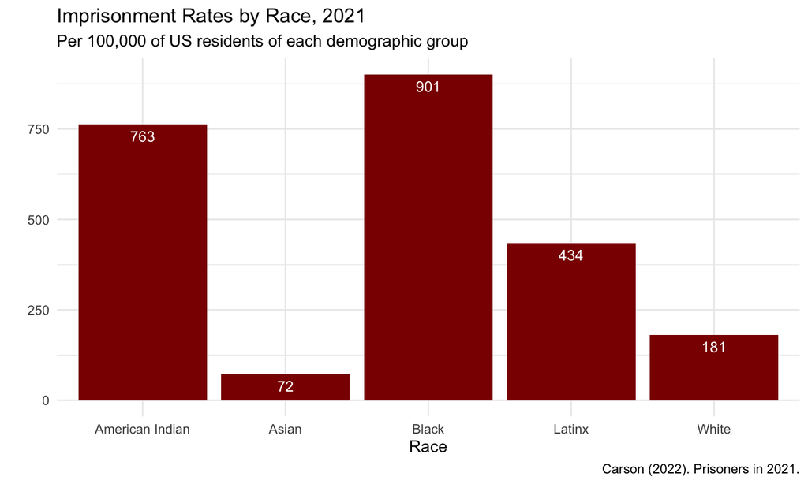

## Prisons

To support our framing of contemporary data, we take on an historical view.

### Federal

Federal racialization data

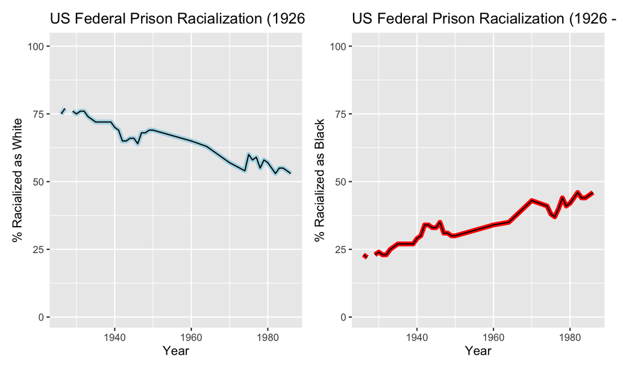

### State

State racialization data

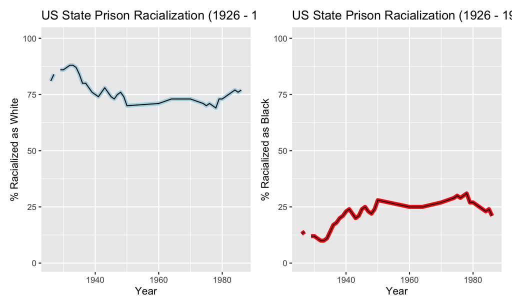

### Federal and State

Federal and State racialization data

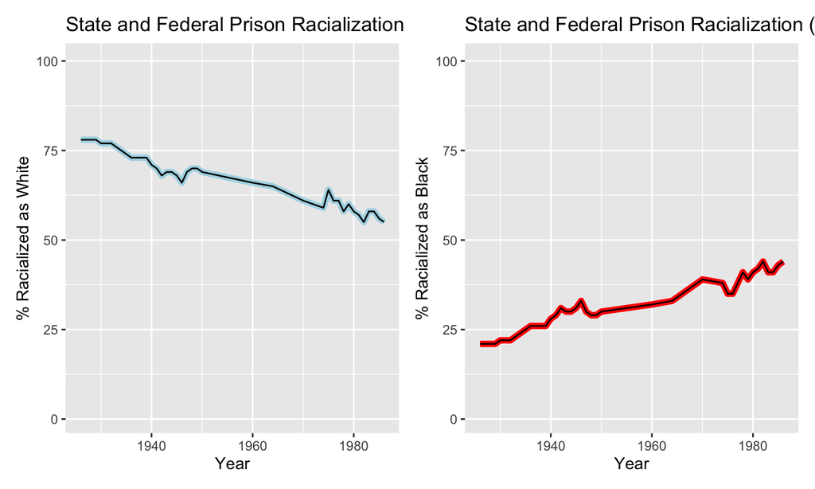

## Racism vs. Anti-Blackness

In a 2020 NY Times article, kihana miraya ross chronicles the realities of anti-Blackness. [ross (2020)](https://www.nytimes.com/2020/06/04/opinion/george-floyd-anti-blackness.html) deals with the related but differing functions of racism and anti-Blackness.

- ross notes that “‘racism’ fails to fully capture what black people in this country are facing.”
- ross continues by noting that “Anti-blackness is one way some black scholars have articulated what it means to be marked as black in an anti-black world.”
- Broadly, ross defines anti-Blackness as society’s inability to recognize Black people’s humanity.

## Broad Implications

- K-12 teaching and learning
  - This also exposes students to a diversity of problems and methods to solve those problems.
- Computationally-focused research and training in higher education
  - Provides an equitable pathway and entry into “high information, high density” conversations.
- Industry and professional organizations

## Gratitude for your time.

. . .

Thank you for joining us and citing today’s presentation.

Alexander, N., Davis, K., Ghali, B., Stewart, Q., & La Cour, G. (2024, April 26). The Principles of Reconstruction: Still a Viable Route to Full Citizenship. *The 2024 Bob Moses Conference*. [Online](https://www.bobmosesconference.com/).